# TASK3： 数据操作-综合分析

姚震林 202411422339

2024-11-05

## 1.

对矩阵进行如下操作：

**a**. 在 `R` 中生成矩阵$A$：
$$A =
\begin{bmatrix}
1 & 2 & 3 \\
4 & 2 & 1 \\
2 & 3 & 0
\end{bmatrix}$$

```r
> A_entries = c(1,2,3,4,2,1,2,3,0)
> A = matrix(A_entries, nrow = 3, byrow = T)
> print(A)
```

```
##      [,1] [,2] [,3]
## [1,]    1    2    3
## [2,]    4    2    1
## [3,]    2    3    0
```

**b**. 计算矩阵$A$的转置矩阵$B$, 以及逆矩阵$C$

```r
> B = t(A)
> C = solve(A)
> cat("转置矩阵 B:\n")
> print(B)
> cat("逆矩阵 C:\n")
> print(C)
```

```
## 转置矩阵 B:
##      [,1] [,2] [,3]
## [1,]    1    4    2
## [2,]    2    2    3
## [3,]    3    1    0
## 逆矩阵 C:
##       [,1]  [,2]  [,3]
## [1,] -0.12  0.36 -0.16
## [2,]  0.08 -0.24  0.44
## [3,]  0.32  0.04 -0.24
```

**c**. 求矩阵$A$和矩阵$B$的乘积

```r
> prod = A %*% B
> print(prod)
```

```
##      [,1] [,2] [,3]
## [1,]   14   11    8
## [2,]   11   21   14
## [3,]    8   14   13
```

## 2.

使用电视剧网播量数据集，该数据集收集了 4266 条电视剧的信息。请完成以下任务。

**a**. 获取数据集，查看数据概况；

```r
> tv_data = read.csv("电视剧播量.csv", fileEncoding = "GBK")
> head(tv_data)
> summary(tv_data)
```

```
##           剧名                                    类型 播放量    点赞    差评
## 1   花千骨2015            言情剧\n/\n穿越剧\n/\n网络剧 3.07亿 992,342 357,808
## 2 还珠格格2015          古装剧\n\n/\n喜剧\n\n/\n网络剧 73.3万   2,352   7,240
## 3         天局 武侠剧\n/\n古装剧\n/\n悬疑剧\n/\n网络剧 3454万  38,746   3,593
## 4     明若晓溪            青春剧\n/\n言情剧\n/\n偶像剧 1.57亿 518,660  72,508
## 5     多情江山            言情剧\n/\n古装剧\n/\n宫廷剧 1126万  22,553   6,955
## 6   我是机器人                       偶像剧\n\n/\n喜剧 1660万  37,905   3,605
##   得分           采集日期
## 1  7.3 2015-9-23 23:48:48
## 2  2.5 2015-9-23 23:48:48
## 3  9.2 2015-9-23 23:48:52
## 4  8.8 2015-9-23 23:48:51
## 5  7.6 2015-9-23 23:48:52
## 6  9.1 2015-9-23 23:48:51
##      剧名               类型              播放量              点赞
##  Length:4266        Length:4266        Length:4266        Length:4266
##  Class :character   Class :character   Class :character   Class :character
##  Mode  :character   Mode  :character   Mode  :character   Mode  :character
##      差评               得分             采集日期
##  Length:4266        Length:4266        Length:4266
##  Class :character   Class :character   Class :character
##  Mode  :character   Mode  :character   Mode  :character
```

**b**. 删除数据集中剧名缺失的值

```r
> missing_count = sum(is.na(tv_data$剧名) | tv_data$剧名 == "")  #检查剧名中有几个缺失值NA or 为空的
> cat("剧名缺失或为空的行数是:", missing_count,"\n")
```

```
## 剧名缺失或为空的行数是: 0
```

此题经检查，存在缺失值，但是被预先命名为`null`了, 以及因此需要将这些为`null`的值清除

```r
> missing_count = sum(is.na(tv_data$剧名) | tv_data$剧名 == "" | tv_data$剧名 == "null") # 检查剧名中有几个缺失值（NA或为空的，包括“null”字符串）
> cat("剧名缺失或为空的行数是:", missing_count, "\n")
>
>
> tv_data_clean = tv_data[!is.na(tv_data$剧名) & tv_data$剧名 != "" & tv_data$剧名 != "null", ] # 清除剧名为NA、为空字符串或“null”的行
>
> summary(tv_data_clean)
```

```
## 剧名缺失或为空的行数是: 47
##      剧名               类型              播放量              点赞
##  Length:4219        Length:4219        Length:4219        Length:4219
##  Class :character   Class :character   Class :character   Class :character
##  Mode  :character   Mode  :character   Mode  :character   Mode  :character
##      差评               得分             采集日期
##  Length:4219        Length:4219        Length:4219
##  Class :character   Class :character   Class :character
##  Mode  :character   Mode  :character   Mode  :character
```

```r
>  mean(tv_data_clean$得分, na.rm = TRUE)
```

```
## [1] NA
```

由此可见数据中还有其他情况，欲计算均值还得进一步处理。

**c**. 不考虑缺失数据影响，计算电视剧的平均得分。

```r
> mean_score = mean(tv_data_clean$得分, na.rm = TRUE) #忽略缺失值的情况下计算样本均值
> cat("不考虑缺失数据的电视剧平均得分为:", mean_score,"\n")
```

```
## 不考虑缺失数据的电视剧平均得分为: NA
```

很明显，这里的变量 `tv_data$得分`中出现了非 `numeric`的变量，

```r
> tv_scoring = as.numeric(tv_data_clean$得分) #将非数值变量转换为NA
> tv_sc_mean = mean(tv_scoring,na.rm = T) #使用na.rm参数来计算忽略NA之后的mean
> cat("不考虑缺失数据的电视剧平均得分为:", tv_sc_mean,"\n")
```

```
## 不考虑缺失数据的电视剧平均得分为: 7.592556
```

## 3.

**a**. 获取数据集，查看数据概况。

```r
> mbgame = read.csv("安卓手机游戏.csv", fileEncoding = "GBK")
> head(mbgame)
> summary(mbgame)
```

```
##             游戏名称 评分     类别 语言 热度 最后更新时间 游戏版本     资费
## 1           捕鱼达人  7.6 益智休闲 中文  95℃   2015-07-29    1.9.0 道具收费
## 2            NBA2K14  7.5 体育运动 中文  94℃   2014-05-27      1.3 完全免费
## 3 愤怒的小鸟六周年版  5.9 益智休闲 中文  93℃   2016-09-29    6.0.3 道具收费
## 4       三国志无双战  5.1 动作游戏 中文  90℃   2012-07-31      1.3 完全免费
## 5      地铁跑酷-冰岛  8.4 益智休闲 中文  89℃   2016-09-23   2.54.0 道具收费
## 6           火箭飞人  8.2 动作游戏 英文  89℃   2016-08-30   1.9.10 完全免费
##                     开发商  支持系统 评论数 喜欢数
## 1                 触控科技   2.3以上   6654    114
## 2                 2K Games   4.0以上  16190   3712
## 3 拓维信息系统股份有限公司   2.3以上   7187    280
## 4       PlayBean Co., Ltd.   2.2以上   9372   1608
## 5                     乐逗   4.0以上   8804    888
## 6        Halfbrick Studios 4.0.3以上   7371    544
##    游戏名称              评分           类别               语言
##  Length:1141        Min.   :1.000   Length:1141        Length:1141
##  Class :character   1st Qu.:5.200   Class :character   Class :character
##  Mode  :character   Median :6.600   Mode  :character   Mode  :character
##                     Mean   :6.611
##                     3rd Qu.:7.900
##                     Max.   :9.600
##                     NA's   :203
##      热度           最后更新时间         游戏版本             资费
##  Length:1141        Length:1141        Length:1141        Length:1141
##  Class :character   Class :character   Class :character   Class :character
##  Mode  :character   Mode  :character   Mode  :character   Mode  :character
##
##
##
##
##     开发商            支持系统             评论数          喜欢数
##  Length:1141        Length:1141        Min.   :    0   Min.   :    0.0
##  Class :character   Class :character   1st Qu.:  446   1st Qu.:   67.0
##  Mode  :character   Mode  :character   Median :  859   Median :  233.0
##                                        Mean   : 2322   Mean   :  786.3
##                                        3rd Qu.: 2510   3rd Qu.:  854.8
##                                        Max.   :96354   Max.   :13323.0
##                                        NA's   :1       NA's   :1
```

**b**. 提取热度中的数值部分，计算各游戏类型的热度均值，找出平均热度最高的游戏类型。

经debugging，检查到本数据 `安卓手机游戏.csv` 的最后一行为`,,,,,,,,,,,`, 数据分析时忽略最后一行

```r
> mbgame = read.csv("安卓手机游戏.csv", fileEncoding = "GBK")[1:(nrow(mbgame)-1),]
>
> library(plyr)
>
> mbgame$热度数值 = as.numeric(gsub("[^0-9]", "", mbgame$热度)) #将°C替换为空，然后转换为数值类型
> avheat = ddply(mbgame, .(类别), function(x) {mean(x$热度数值)})
> avheat_withunit = data.frame(类别 = avheat$类别,
+                              平均热度 = paste(avheat$V1,"°C"))
> highestheat = avheat_withunit[which.max(avheat$V1), ]
>
>
> print(avheat_withunit)
> cat("\n","最高平均热度的游戏类型为:",highestheat[1,1],"平均热度为",highestheat[1,2], "\n")
```

```
##        类别            平均热度
## 1  策略塔防 40.8888888888889 °C
## 2  动作游戏 42.6029411764706 °C
## 3  飞行游戏 41.6486486486486 °C
## 4  格斗游戏 40.5714285714286 °C
## 5  角色扮演 42.1929824561403 °C
## 6  竞速游戏 45.6117647058824 °C
## 7  冒险解谜 39.5232558139535 °C
## 8  模拟经营 38.3207547169811 °C
## 9  棋牌游戏 37.0555555555556 °C
## 10 射击游戏 39.9636363636364 °C
## 11 体育运动 45.9782608695652 °C
## 12 养成游戏 42.3333333333333 °C
## 13 益智休闲 41.7979452054795 °C
## 14 音乐游戏             40.6 °C
## 15 游戏工具 43.6153846153846 °C
##
##  最高平均热度的游戏类型为: 体育运动 平均热度为 45.9782608695652 °C
```

**c**. 计算各游戏类型的平均评分、最高评分、最低评分、评分标准差，并作简要分析。

```r
> sum(is.na(mbgame$评分))
```

```
## [1] 202
```

经检查，`评分` 变量中有空值

```r
> library(dplyr)
>
> game_stats = mbgame %>%
+   group_by(类别) %>%
+   summarize(
+     平均评分 = mean(评分, na.rm = TRUE),
+     最高评分 = max(评分, na.rm = TRUE),
+     最低评分 = min(评分, na.rm = TRUE),
+     评分标准差 = sd(评分, na.rm = TRUE)
+   )
>
> print(game_stats)
```

```
## # A tibble: 15 × 5
##    类别     平均评分 最高评分 最低评分 评分标准差
##    <chr>       <dbl>    <dbl>    <dbl>      <dbl>
##  1 体育运动     6.84      8.8      4.9       1.46
##  2 养成游戏     6.55      8.3      5         1.23
##  3 冒险解谜     6.86      9        4.8       1.23
##  4 动作游戏     6.65      9        1         1.44
##  5 射击游戏     6.61      8.6      4.7       1.30
##  6 格斗游戏     6.78      8.8      5         1.18
##  7 棋牌游戏     5.84      8.1      4.5       1.22
##  8 模拟经营     6.67      9.3      4.7       1.28
##  9 游戏工具     5.03      6.4      1         1.63
## 10 益智休闲     6.46      9.6      4.6       1.31
## 11 竞速游戏     6.37      8.8      4.7       1.35
## 12 策略塔防     6.88      9.3      4.8       1.39
## 13 角色扮演     7.00      9.1      4.6       1.33
## 14 音乐游戏     6.4       9        5         1.34
## 15 飞行游戏     5.70      8.2      4.7       1.09
```

```r
> game_stats = summarize(
+   group_by(mbgame, 类别),
+   平均评分 = mean(评分, na.rm = TRUE),
+   最高评分 = max(评分, na.rm = TRUE),
+   最低评分 = min(评分, na.rm = TRUE),
+   评分标准差 = sd(评分, na.rm = TRUE)
+ )
> print(game_stats)
```

```
## # A tibble: 15 × 5
##    类别     平均评分 最高评分 最低评分 评分标准差
##    <chr>       <dbl>    <dbl>    <dbl>      <dbl>
##  1 体育运动     6.84      8.8      4.9       1.46
##  2 养成游戏     6.55      8.3      5         1.23
##  3 冒险解谜     6.86      9        4.8       1.23
##  4 动作游戏     6.65      9        1         1.44
##  5 射击游戏     6.61      8.6      4.7       1.30
##  6 格斗游戏     6.78      8.8      5         1.18
##  7 棋牌游戏     5.84      8.1      4.5       1.22
##  8 模拟经营     6.67      9.3      4.7       1.28
##  9 游戏工具     5.03      6.4      1         1.63
## 10 益智休闲     6.46      9.6      4.6       1.31
## 11 竞速游戏     6.37      8.8      4.7       1.35
## 12 策略塔防     6.88      9.3      4.8       1.39
## 13 角色扮演     7.00      9.1      4.6       1.33
## 14 音乐游戏     6.4       9        5         1.34
## 15 飞行游戏     5.70      8.2      4.7       1.09
```

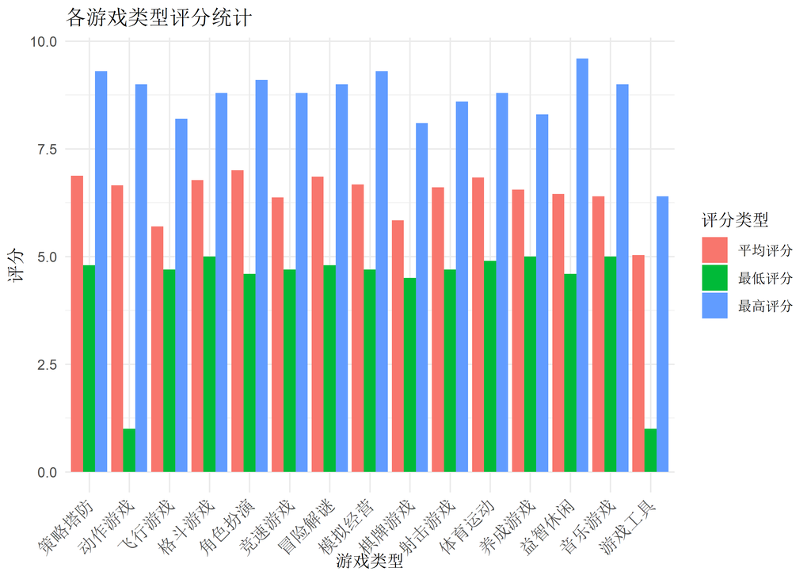

```r
> library(ggplot2)
>
> library(tidyr)
> game_stats_long = game_stats %>%
+   pivot_longer(cols = c(平均评分, 最高评分, 最低评分),
+                names_to = "评分类型",
+                values_to = "评分")
>
> ggplot(game_stats_long, aes(x = 类别, y = 评分, fill = 评分类型)) +
+   geom_bar(stat = "identity", position = "dodge") +
+   labs(title = "各游戏类型评分统计",
+        x = "游戏类型",
+        y = "评分") +
+   theme_minimal() +
+   theme(axis.text.x = element_text(angle = 45, hjust = 1))
```

由结果可知，`飞行游戏`这一类游戏虽然波动最小（标准差最低），但是平均评分不高，显然作为玩家会更青睐有优秀作品的类型诸如拥有高的最高评分的`益智休闲`以及`策略塔防`的游戏类别。`游戏工具`这一类游戏，平均分，最高分，最低分都是最低的，与此同时波动还大；此外其他类型的游戏之间差距不是太大